# DM hw 8

Thien Pham

# Preparing workspace

```r
options(
  digits = 5,
  scipen = 999,
  warn = -1
)
rm(
  list = ls()
)
library(magrittr)
```

# Loading in data

```r
Facebook <- readr::read_csv(
  file = "/Users/thienpham/Data Mining/Data/Prepared_Facebook.csv",
  col_types = "ncnnnnnnnnnnnnnnnnnnnnnnnnnnnnnnnnnnnnnnnnnnnnnnn"
) %>%
  as.data.frame()
```

# Standardizing features

```r
numeric.pred <- c("page.like","unique.views","nonunique.views","unique.clickers","nonunique.clickers",
                                  "total.clicks","views.by.liker","views.by.unique.likers",
                                  "clicks.by.liker","comment","like","share","hour")
sapply(
  X = Facebook[,numeric.pred],
  FUN = sd
)
```

```
##              page.like           unique.views        nonunique.views
##            16147.97501                1.11760                1.14251
##        unique.clickers     nonunique.clickers           total.clicks
##                0.83847                0.85876                0.95267
##         views.by.liker views.by.unique.likers        clicks.by.liker
##                0.99012                0.93461                0.78983
##                comment                   like                  share
##                0.80312                2.85442                1.87630
##                   hour
##                4.30573
```

```r
Facebook[,numeric.pred] <- scale(
  x = Facebook[,numeric.pred]
)
```

# Using cross validation to determine optimal lambda values

```r
set.seed(1)
Facebook$partition <- sample(
  x = c("train", "test"),
  size = nrow(Facebook),
  replace = TRUE,
  prob = c(0.85,0.15)
)

v_predictors <- names(Facebook)[c(1:18,22:49)]

cv.ridge <- glmnet::cv.glmnet(
  x = Facebook[,v_predictors] %>%
    dplyr::filter(Facebook$partition == "train") %>%
    as.matrix(),
  y = Facebook$YJ.total.interactions[Facebook$partition == "train"],
  alpha = 0
)
cv.ridge
```

```
##
## Call:  glmnet::cv.glmnet(x = Facebook[, v_predictors] %>% dplyr::filter(Facebook$partition ==      "train") %>% as.matrix(), y = Facebook$YJ.total.interactions[Facebook$partition ==      "train"], alpha = 0)
##
## Measure: Mean-Squared Error
##
##     Lambda Index Measure     SE Nonzero
## min  0.229   100   0.142 0.0451      45
## 1se  0.332    96   0.177 0.0474      45
```

The minimum penalty lambda = 0.229 and the largest lambda within 1 standard error of the minimum = 0.332. We will go with lambda = 0.332 for ridge. The following plot shows that we are gaining more by using a higher lambda value without before being significantly affected by greater error.

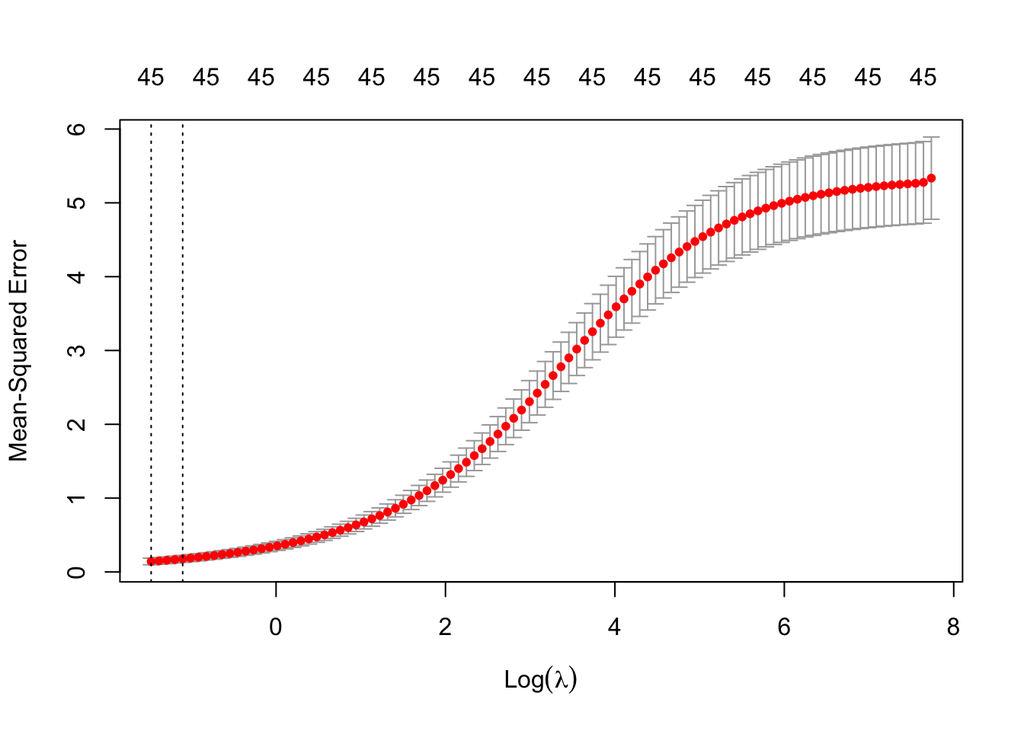

```r
plot(
  x = cv.ridge
)
```

```r
cv.lasso <- glmnet::cv.glmnet(
  x = Facebook[,v_predictors] %>%
    dplyr::filter(Facebook$partition == "train") %>%
    as.matrix(),
  y = Facebook$YJ.total.interactions[Facebook$partition == "train"],
  alpha = 1
)
cv.lasso
```

```
##
## Call:  glmnet::cv.glmnet(x = Facebook[, v_predictors] %>% dplyr::filter(Facebook$partition ==      "train") %>% as.matrix(), y = Facebook$YJ.total.interactions[Facebook$partition ==      "train"], alpha = 1)
##
## Measure: Mean-Squared Error
##
##     Lambda Index Measure     SE Nonzero
## min 0.0165    54  0.0611 0.0385      11
## 1se 0.1692    29  0.0966 0.0507       2
```

The minimum penalty lambda = 0.0165 and the largest lambda within 1 standard error of the minimum = 0.1692. We will go with lambda = 0.1692 for lasso.

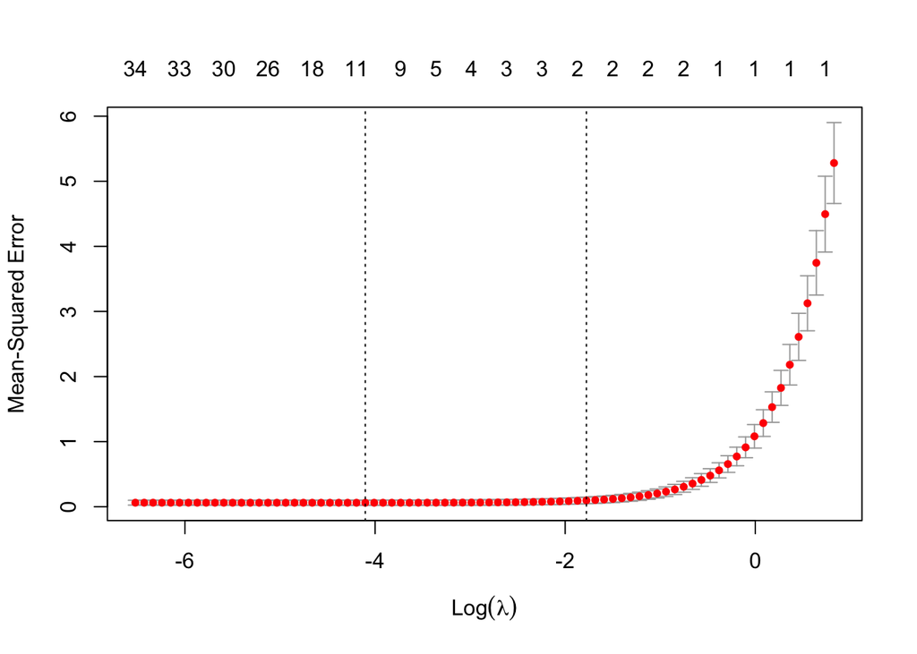

```r
plot(
  x = cv.lasso
)
```

```r
cv.elasticnet <- glmnet::cv.glmnet(
  x = Facebook[,v_predictors] %>%
    dplyr::filter(Facebook$partition == "train") %>%
    as.matrix(),
  y = Facebook$YJ.total.interactions[Facebook$partition == "train"],
  alpha = 0.5
)
cv.elasticnet
```

```
##
## Call:  glmnet::cv.glmnet(x = Facebook[, v_predictors] %>% dplyr::filter(Facebook$partition ==      "train") %>% as.matrix(), y = Facebook$YJ.total.interactions[Facebook$partition ==      "train"], alpha = 0.5)
##
## Measure: Mean-Squared Error
##
##     Lambda Index Measure     SE Nonzero
## min 0.0043    76  0.0621 0.0399      33
## 1se 0.1936    35  0.0963 0.0566       6
```

The minimum penalty lambda = 0.0043 and the largest lambda within 1 standard error of the minimum = 0.1936. We will go with lambda = 0.1936.

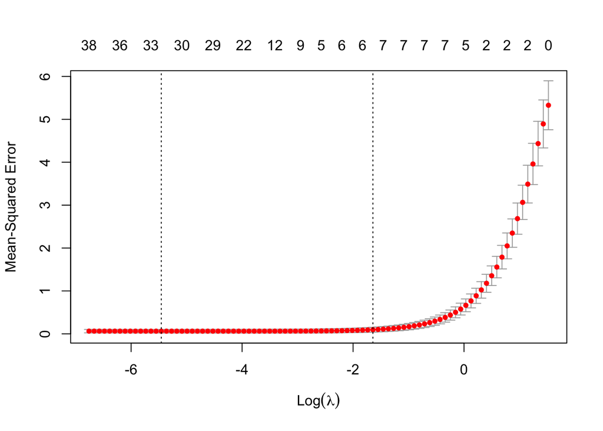

```r
plot(
  x = cv.elasticnet
)
```

# Using optimal lambda to fit ridge, lasso, and elastic net

```r
ridge <- glmnet::glmnet(
  x = Facebook[,v_predictors] %>%
    dplyr::filter(Facebook$partition == "train") %>%
    as.matrix(),
  y = Facebook$YJ.total.interactions[Facebook$partition == "train"],
  alpha = 0,
  lambda = 0.332
)
ridge
```

```
##
## Call:  glmnet::glmnet(x = Facebook[, v_predictors] %>% dplyr::filter(Facebook$partition ==      "train") %>% as.matrix(), y = Facebook$YJ.total.interactions[Facebook$partition ==      "train"], alpha = 0, lambda = 0.332)
##
##   Df %Dev Lambda
## 1 45 97.2  0.332
```

```r
coef(
  object = ridge
) %>%
  as.matrix() %>%
  as.data.frame() %>%
  dplyr::arrange(s0)
```

```
##                                 s0
## TypeStatus             -0.43221133
## TypeVideo              -0.27266167
## Category1              -0.16832713
## month2                 -0.12941539
## month6                 -0.12923246
## month10                -0.08800692
## day7                   -0.07120833
## month3                 -0.06854719
## month1                 -0.05449132
## month4                 -0.04118035
## nonunique.clickers     -0.02413473
## day2                   -0.02186910
## day3                   -0.01662638
## month8                 -0.00974177
## day                    -0.00797938
## Paid0                  -0.00290411
## day5                   -0.00279101
## hour                   -0.00048051
## Type                    0.00000000
## Paid1                   0.00335893
## Paid                    0.00366279
## month                   0.01539798
## day6                    0.01711909
## total.clicks            0.01867571
## month7                  0.03605301
## day1                    0.04632718
## day4                    0.05453397
## page.like               0.05779379
## nonunique.views         0.06159605
## views.by.liker          0.06195408
## month5                  0.06418289
## Category3               0.06512754
## month12                 0.06815569
## views.by.unique.likers  0.07337607
## Category                0.07508350
## unique.views            0.09069644
## month9                  0.09594126
## clicks.by.liker         0.14013275
## unique.clickers         0.14474672
## Category2               0.14528806
## comment                 0.18832010
## TypePhoto               0.21398178
## month11                 0.23252160
## TypeLink                0.28726184
## share                   0.54387840
## like                    1.12007050
## (Intercept)             6.89966525
```

```r
lasso <- glmnet::glmnet(
  x = Facebook[,v_predictors] %>%
    dplyr::filter(Facebook$partition == "train") %>%
    as.matrix(),
  y = Facebook$YJ.total.interactions[Facebook$partition == "train"],
  alpha = 1,
  lambda = 0.1692
)
lasso
```

```
##
## Call:  glmnet::glmnet(x = Facebook[, v_predictors] %>% dplyr::filter(Facebook$partition ==      "train") %>% as.matrix(), y = Facebook$YJ.total.interactions[Facebook$partition ==      "train"], alpha = 1, lambda = 0.1692)
##
##   Df %Dev Lambda
## 1  2 98.2  0.169
```

```r
coef(
  object = lasso
) %>%
  as.matrix() %>%
  as.data.frame() %>%
  dplyr::arrange(s0)
```

```
##                             s0
## page.like              0.00000
## Type                   0.00000
## Category               0.00000
## month                  0.00000
## day                    0.00000
## hour                   0.00000
## Paid                   0.00000
## unique.views           0.00000
## nonunique.views        0.00000
## unique.clickers        0.00000
## nonunique.clickers     0.00000
## total.clicks           0.00000
## views.by.liker         0.00000
## views.by.unique.likers 0.00000
## clicks.by.liker        0.00000
## comment                0.00000
## TypeLink               0.00000
## TypePhoto              0.00000
## TypeStatus             0.00000
## TypeVideo              0.00000
## month1                 0.00000
## month10                0.00000
## month11                0.00000
## month12                0.00000
## month2                 0.00000
## month3                 0.00000
## month4                 0.00000
## month5                 0.00000
## month6                 0.00000
## month7                 0.00000
## month8                 0.00000
## month9                 0.00000
## Category1              0.00000
## Category2              0.00000
## Category3              0.00000
## day1                   0.00000
## day2                   0.00000
## day3                   0.00000
## day4                   0.00000
## day5                   0.00000
## day6                   0.00000
## day7                   0.00000
## Paid0                  0.00000
## Paid1                  0.00000
## share                  0.18752
## like                   2.00108
## (Intercept)            7.25374
```

```r
elasticnet <- glmnet::glmnet(
  x = Facebook[,v_predictors] %>%
    dplyr::filter(Facebook$partition == "train") %>%
    as.matrix(),
  y = Facebook$YJ.total.interactions[Facebook$partition == "train"],
  alpha = 0.5,
  lambda = 0.1936
)
elasticnet
```

```
##
## Call:  glmnet::glmnet(x = Facebook[, v_predictors] %>% dplyr::filter(Facebook$partition ==      "train") %>% as.matrix(), y = Facebook$YJ.total.interactions[Facebook$partition ==      "train"], alpha = 0.5, lambda = 0.1936)
##
##   Df %Dev Lambda
## 1  7 98.3  0.194
```

```r
coef(
  object = elasticnet
) %>%
  as.matrix() %>%
  as.data.frame() %>%
  dplyr::arrange(s0)
```

```
##                               s0
## page.like              0.0000000
## Type                   0.0000000
## Category               0.0000000
## month                  0.0000000
## day                    0.0000000
## hour                   0.0000000
## Paid                   0.0000000
## nonunique.clickers     0.0000000
## total.clicks           0.0000000
## views.by.liker         0.0000000
## views.by.unique.likers 0.0000000
## TypeLink               0.0000000
## TypePhoto              0.0000000
## TypeStatus             0.0000000
## TypeVideo              0.0000000
## month1                 0.0000000
## month10                0.0000000
## month11                0.0000000
## month12                0.0000000
## month2                 0.0000000
## month3                 0.0000000
## month4                 0.0000000
## month5                 0.0000000
## month6                 0.0000000
## month7                 0.0000000
## month8                 0.0000000
## month9                 0.0000000
## Category1              0.0000000
## Category2              0.0000000
## Category3              0.0000000
## day1                   0.0000000
## day2                   0.0000000
## day3                   0.0000000
## day4                   0.0000000
## day5                   0.0000000
## day6                   0.0000000
## day7                   0.0000000
## Paid0                  0.0000000
## Paid1                  0.0000000
## unique.views           0.0015906
## clicks.by.liker        0.0108823
## nonunique.views        0.0153506
## unique.clickers        0.0429559
## comment                0.0912661
## share                  0.3969836
## like                   1.7101377
## (Intercept)            7.2543326
```

For ridge, we can see that the coefficient values towards the middle have the least effect. For lasso, only 2 variables are kept: share and like. Since elastic net is a combination of both lasso and ridge, we see that some variables have a coefficient of 0 as well as others still hanging on but having a very small coefficient. This gives us a better model in this case because the selected variables make more sense from a subject point of view.

# Testing varying lambdas on lasso

In the previous lasso model, a lambda of 0.1692 eliminated nearly all of the predictor variables, keeping 2.

```r
lasso <- glmnet::glmnet(
  x = Facebook[,v_predictors] %>%
    dplyr::filter(Facebook$partition == "train") %>%
    as.matrix(),
  y = Facebook$YJ.total.interactions[Facebook$partition == "train"],
  alpha = 1,
  lambda = 3
)
lasso
```

```
##
## Call:  glmnet::glmnet(x = Facebook[, v_predictors] %>% dplyr::filter(Facebook$partition ==      "train") %>% as.matrix(), y = Facebook$YJ.total.interactions[Facebook$partition ==      "train"], alpha = 1, lambda = 3)
##
##   Df %Dev Lambda
## 1  0    0      3
```

```r
coef(
  object = lasso
) %>%
  as.matrix() %>%
  as.data.frame() %>%
  dplyr::arrange(s0)
```

```
##                            s0
## page.like              0.0000
## Type                   0.0000
## Category               0.0000
## month                  0.0000
## day                    0.0000
## hour                   0.0000
## Paid                   0.0000
## unique.views           0.0000
## nonunique.views        0.0000
## unique.clickers        0.0000
## nonunique.clickers     0.0000
## total.clicks           0.0000
## views.by.liker         0.0000
## views.by.unique.likers 0.0000
## clicks.by.liker        0.0000
## comment                0.0000
## like                   0.0000
## share                  0.0000
## TypeLink               0.0000
## TypePhoto              0.0000
## TypeStatus             0.0000
## TypeVideo              0.0000
## month1                 0.0000
## month10                0.0000
## month11                0.0000
## month12                0.0000
## month2                 0.0000
## month3                 0.0000
## month4                 0.0000
## month5                 0.0000
## month6                 0.0000
## month7                 0.0000
## month8                 0.0000
## month9                 0.0000
## Category1              0.0000
## Category2              0.0000
## Category3              0.0000
## day1                   0.0000
## day2                   0.0000
## day3                   0.0000
## day4                   0.0000
## day5                   0.0000
## day6                   0.0000
## day7                   0.0000
## Paid0                  0.0000
## Paid1                  0.0000
## (Intercept)            7.2346
```

Using a large lambda value of 3, we see that no variables are kept. This further shows that a larger lambda imposes a stronger penalty.

```r
lasso <- glmnet::glmnet(
  x = Facebook[,v_predictors] %>%
    dplyr::filter(Facebook$partition == "train") %>%
    as.matrix(),
  y = Facebook$YJ.total.interactions[Facebook$partition == "train"],
  alpha = 1,
  lambda = 0.0004
)
lasso
```

```
##
## Call:  glmnet::glmnet(x = Facebook[, v_predictors] %>% dplyr::filter(Facebook$partition ==      "train") %>% as.matrix(), y = Facebook$YJ.total.interactions[Facebook$partition ==      "train"], alpha = 1, lambda = 0.0004)
##
##   Df %Dev Lambda
## 1 38 99.1 0.0004
```

```r
coef(
  object = lasso
) %>%
  as.matrix() %>%
  as.data.frame() %>%
  dplyr::arrange(s0)
```

```
##                                             s0
## views.by.unique.likers -0.21592028994587819657
## unique.clickers        -0.18490169088742477999
## TypeStatus             -0.16469519987587305510
## Category3              -0.16150021034978986889
## month10                -0.09861897880875782063
## TypeVideo              -0.09425985843180770263
## month8                 -0.05441016147144361881
## month9                 -0.04278548339685101648
## day7                   -0.03132523292193870046
## Paid0                  -0.02207016047563734387
## day4                   -0.01958593783662298735
## month5                 -0.01165302124428697038
## month3                 -0.01009174546919426943
## unique.views           -0.00777675410589036189
## hour                   -0.00587250480647755115
## day5                   -0.00433312279151680871
## Category1              -0.00048546683193017578
## day                    -0.00007968412493261737
## Type                    0.00000000000000000000
## month                   0.00000000000000000000
## Paid                    0.00000000000000000000
## total.clicks            0.00000000000000000000
## TypePhoto               0.00000000000000000000
## month2                  0.00000000000000000000
## month6                  0.00000000000000000000
## day1                    0.00000000000000000000
## Paid1                   0.00000000000000040395
## Category2               0.00012683569330158742
## day6                    0.00419193269807095325
## day2                    0.01227813793043508461
## page.like               0.01885398925788363961
## month4                  0.02946452215756922843
## month11                 0.04987565073893133333
## nonunique.views         0.05065615503181599560
## month12                 0.05625379251944858522
## day3                    0.05899846622070397534
## comment                 0.08123389670643339777
## month7                  0.08978446103960327496
## Category                0.10167927617280224373
## views.by.liker          0.11878276979213814313
## month1                  0.12161907766291396582
## clicks.by.liker         0.12351754896326079536
## nonunique.clickers      0.16822694895351064659
## TypeLink                0.18027491595026828852
## share                   0.23287247657512230581
## like                    2.05720296761320842194
## (Intercept)             7.12715956466579836359
```

With a lower lambda value, it is expected that more variables are kept. With such a low value, we can see that all but 8 variables are kept.

# Comparing performance on test set

Earlier, the %Dev for ridge, lasso, and elastic net were: 97.2%, 98.2%, 98.3% respectively

```r
ridge <- glmnet::glmnet(
  x = Facebook[,v_predictors] %>%
    dplyr::filter(Facebook$partition == "test") %>%
    as.matrix(),
  y = Facebook$YJ.total.interactions[Facebook$partition == "test"],
  alpha = 0,
  lambda = 0.3321
)
ridge
```

```
##
## Call:  glmnet::glmnet(x = Facebook[, v_predictors] %>% dplyr::filter(Facebook$partition ==      "test") %>% as.matrix(), y = Facebook$YJ.total.interactions[Facebook$partition ==      "test"], alpha = 0, lambda = 0.3321)
##
##   Df %Dev Lambda
## 1 45 98.3  0.332
```

The %Dev increased to 98.3%.

```r
lasso <- glmnet::glmnet(
  x = Facebook[,v_predictors] %>%
    dplyr::filter(Facebook$partition == "test") %>%
    as.matrix(),
  y = Facebook$YJ.total.interactions[Facebook$partition == "test"],
  alpha = 1,
  lambda = 0.16917
)
lasso
```

```
##
## Call:  glmnet::glmnet(x = Facebook[, v_predictors] %>% dplyr::filter(Facebook$partition ==      "test") %>% as.matrix(), y = Facebook$YJ.total.interactions[Facebook$partition ==      "test"], alpha = 1, lambda = 0.16917)
##
##   Df %Dev Lambda
## 1  4 98.5  0.169
```

The %Dev increased to 98.5%.

```r
elasticnet <- glmnet::glmnet(
  x = Facebook[,v_predictors] %>%
    dplyr::filter(Facebook$partition == "test") %>%
    as.matrix(),
  y = Facebook$YJ.total.interactions[Facebook$partition == "test"],
  alpha = 0.5,
  lambda = 0.21249
)
elasticnet
```

```
##
## Call:  glmnet::glmnet(x = Facebook[, v_predictors] %>% dplyr::filter(Facebook$partition ==      "test") %>% as.matrix(), y = Facebook$YJ.total.interactions[Facebook$partition ==      "test"], alpha = 0.5, lambda = 0.21249)
##
##   Df %Dev Lambda
## 1  6 98.6  0.212
```

The %Dev increased to 98.6%.

In the real world, feature selection can reduce cost and minimize overfitting. We would prefer lasso over ridge when we need to perform feature selection since the penalty assigns a 0 to variables essentially eliminating the variable. We would prefer ridge over lasso when all variables need to be present in the model for legal reasons.